# LLMs

Author

Ben Bolker

Published

September 8, 2026

Some thoughts on *large language models* (Gemini, ChatGPT, Microsoft Copilot, Claude, etc.). They are intended as a jumping-off point for class discussion.

They’re focused on use in undergraduate coursework, and are opinionated.

## Beneficial uses of LLMs

- Act as a personal tutor; answer questions, pose questions, give examples …
- Eliminate drudgery, allow you to focus on more important parts of their education
- Learning how to use LLMs more effectively, for future career etc.
- From Carrigan (2025), quoted by Heard (2025a):

> “rubberducking” (explaining your ideas to an LLM to test and polish your ability to explain them, just as you might talk your ideas out to a friend, or your cat, or a rubber duck); asking an LLM to summarize your draft, using its errors to diagnose gaps in what you’ve written; and using an LLM to assist with translation of text between audiences (paper to blog post, for example)

Carrigan advocates the use of LLMs as “interlocutors” by scholars (I’m not sure I agree)

## Downsides of LLMs

- Helps you avoid exercising your brain and actually learning stuff; short-circuits the learning process
- In order to understand when LLMs are wrong (hallucinations, bullshit, confident but incorrect answers) you already need to know *the things you’re trying to learn in class*
- Do LLMs make your writing better or worse (or more average, i.e. regression to the mean?)
- Increased dependence on mega-corporations

## LLM concerns

- Water/energy usage (but see ScientistSeesSquirrel (2025))
- AI slop
- Privacy
- Intellectual property/fair use
- Algorithmic bias
- Equity (access to professional/$$ AI versions)
- Displacement of jobs, especially creative jobs
- Enhanced cheating on academic assessments
- Concentration of power in Big Tech
- Existential threats (????)

## Analogies

Are LLMs more like a:

- calculator?
- symbolic algebra package (e.g. Mathematica, Maple)?
- statistics package?
- spell-checker?
- navigation aid?
- compiler for programming languages?
- forklift (at the gym)? (attributed to [Sanmay Das](https://people.cs.vt.edu/sanmay/))

What tasks are we off-loading to the computer, and what is the value of being able to do those tasks unassisted? Should you have to learn to do stuff before you’re allowed to let the computer do it for you?

(Discuss.)

## using LLMs effectively

- Checking results (common sense, following up references)
- Attribution (e.g. [McMaster Research Guide on citing AI](https://libguides.mcmaster.ca/cite-gen-ai))
- Prompt engineering

Some fun references:

- Sheckley (1954)
- Rik Blok (2019) (I used Copilot to find this!)
- Bergstrom and West (2020) https://thebullshitmachines.com/
- Stephen Heard blog posts: Heard (2025b), Heard (2024)

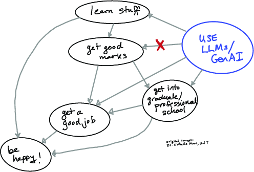

## survey (2026 ISCI math version)

[figure not shown]

## References

Bergstrom, Carl T., and Jevin D. West. 2020. *Calling Bullshit: The Art of Skepticism in a Data-Driven World*. New York: Random House Trade Paperbacks.

Carrigan, Mark. 2025. *Generative AI for Academics*. London ; Thousand Oaks, California: SAGE Publications Ltd.

Heard, Stephen. 2024. “Navigating the Evangelical Fervour of AI Absolutism.” *Scientist Sees Squirrel*. https://scientistseessquirrel.wordpress.com/2024/10/01/navigating-the-evangelical-fervour-of-ai-absolutism/.

———. 2025a. “Three Books to Sum up Where We’re at with ‘AI’ Tools for Writing.” *Scientist Sees Squirrel*. https://scientistseessquirrel.wordpress.com/2025/02/11/three-books-to-sum-up-where-were-at-with-ai-tools-for-writing/.

———. 2025b. “Making ChatGPT Write Badly (for Use in Teaching): An Example, and Lessons.” *Scientist Sees Squirrel*. https://scientistseessquirrel.wordpress.com/2025/07/08/making-chatgpt-write-badly-for-use-in-teaching-an-example-and-lessons/.

Rik Blok. 2019. “Real Genius Classroom Montage (1985).” https://www.youtube.com/watch?v=wB1X4o-MV6o.

ScientistSeesSquirrel. 2025. “No, the Plagiarism Machine Isn’t Burning down the Planet (New AI Energy-Use Estimates).” *Scientist Sees Squirrel*.

Sheckley, Robert. 1954. “The Battle.” *Worlds of IF*, September, 52–56. https://archive.org/details/1954-09_IF.